```python
from vectorbtpro import *

from datetime import datetime
from dateutil.relativedelta import relativedelta

from pypfopt.objective_functions import transaction_cost
from pypfopt.expected_returns import mean_historical_return
from pypfopt.risk_models import CovarianceShrinkage
from pypfopt.efficient_frontier import EfficientFrontier
```

```python
vbt.settings.set_theme("dark")
```

# Portfolio Optimization

[figure not shown]

Acknowledgements:

We will be using [vector-bt](https://github.com/polakowo/vectorbt), a (semi-)professional vectorized backtesting library written in Python, written by Oleg Polakow.

**Note:** For detailed documentation see [documentation](https://vectorbt.pro/pvt_74d2a4ff/tutorials/portfolio-optimization/)

Financial markets are highly nondeterministic. We want to find the portfolio that offers us high returns at low risk under the following market assumptions.

1. Rational decision-makers: Investors want to maximise return while reducing the risks associated with their investment
2. **No arbitrage** : cannot make a costless, riskless profit
3. Risky securities : $\{S_1,\ldots,S_n\}:\, n\geq 2$ be risky securities whose future returns are uncertain. There is no risk-free asset $S_0$ in our portfolio
4. Equilibrium : supply equals demand for securities
5. Liquidity : any # of units of a security can be bought and sold quickly
6. Access to information : rapid availability of accurate information
7. **Price is efficient** : Price of security adjusts immediately to new information, and current price reflects past information and expected further behaviour
8. No transaction costs and taxes : transaction costs are assumed to be negligible compared to value of trades (*we may relax this assumption and assume cost* $K$ *per transaction*) and are ignored. No taxes (capital-gains etc.) on transactions.

We want to select a portfolio $\mathbf{x}=(x_1,\ldots,x_n)\in\mathbb{R}^n$ where $x_i$ is the amount (fraction of budget) invested in security $S^i$. We work in **discrete-time**, so we only consider now ($t=0$) and a moment in time in the future ($t=1$)

The return of asset $i$ is a random variable $r_i:\Omega \rightarrow [0,\infty)$ where $\Omega$ is the sample space (set of scenarios for the future). If $S_t^i:\Omega\rightarrow\mathbb{R}_+$ is the random variable denoting the future value of asset $i$ at time $t$. Then under scenario $\omega\in\Omega$, we have that $r_i(\omega)=S^i_1(\omega)/S_0^i$. So for instance, a $5\%$ return on asset $i$ corresponds to $r_i=1.05$ and $-2%$ return corresponds to $r_i=0.98$

$\newcommand{\x}{\mathbf{x}}$ Let $r = (r_1,\ldots, r_n)$ denote the random vector of returns with mean $\mu=\mathbf{E}[r]\in\mathbb{R}^n$ and covariance matrix $\Sigma\in\mathbb{R}^{n\times n}$. Let the set of admissible portfolios be denoted by $X=\{\x\in\mathbb{R}^n:\sum_{i=0}^n x_i=1,\, \x\geq 0\}\subset\mathbb{R}^n$. In other words, we do not allow short-selling (for now), and must always be fully-allocated.

Then the **return of portfolio** $\mathcal{R}:X\rightarrow \mathbb{R}$ is given by $\mathcal{R}(\x)=r^T\x \implies \mathbf{E}[\mathcal{R}] = \mu^T\x$.

The **risk of portfolio** $\x\in X$ is denoted $\text{Risk}(\x)\equiv\text{Risk}(\mathcal{R}(\x))$ where $\text{Risk}:X\rightarrow\mathbb{R}$ is the risk measure.

### Data Fetching

```python
END_DATE = datetime.today().strftime("%Y-%m-%d")
START_DATE = (datetime.today() - relativedelta(years=3)).strftime("%Y-%m-%d")
```

```python
data = vbt.YFData.pull(
    ["BTC-USD", "ETH-USD", "XMR-USD", "LINK-USD"],
    start=f"{START_DATE} UTC",
    end=f"{END_DATE} UTC",
    timeframe="1d"
)

#data.to_hdf("data/BinanceData.h5") # save data to disk
#data = vbt.HDFData.pull("data/BinanceData.h5") # retrieve data from disk
```

The object returned inherits from the `vectorbtpro.data` base class, which is very extensible, but for modeling purposes we only really care about OHLC data.

```python
df = data.get("close")
df.tail()
```

| symbol Date | BTC-USD | ETH-USD | XMR-USD | LINK-USD |
| --- | --- | --- | --- | --- |
| 2026-02-21 00:00:00+00:00 | 68003.765625 | 1973.737183 | 326.570953 | 8.876016 |
| 2026-02-22 00:00:00+00:00 | 67659.390625 | 1957.805908 | 327.830200 | 8.672669 |
| 2026-02-23 00:00:00+00:00 | 64616.738281 | 1855.502808 | 307.265533 | 8.265229 |
| 2026-02-24 00:00:00+00:00 | 64080.042969 | 1852.969482 | 321.333679 | 8.203102 |
| 2026-02-25 00:00:00+00:00 | 67960.125000 | 2054.627930 | 344.504822 | 9.256296 |

### Optimization

$\newcommand{\x}{\mathbf{x}}$ $\newcommand{\R}{\mathbb{R}}$

We want to maximize expected return while minimizing risk

[figure not shown]

Here we consider the risk-return trade-off:$\quad \max\; \{\mu^T\x -\delta\text{Risk}(x)\, |\, \x\in X \}\quad \text{where}\quad X=\{\x\in(-1,1)^n\, |\, \x^T\mathbf{1}=1 \}$

```python
def mean_var(x, mu, cov_matrix, delta):
    var = x.T @ (cov_matrix * np.eye(cov_matrix.shape[0])) @ x
    return -((mu.T @ x) - delta * var)

def optimize_func(price, index_slice):
    price_filt = price.iloc[index_slice]
    mu = mean_historical_return(price_filt)
    S = CovarianceShrinkage(price_filt).ledoit_wolf()
    ef = EfficientFrontier(mu, S, weight_bounds=(0.01, 0.3))
    ef.convex_objective(mean_var, mu=mu.values, cov_matrix=S.values, delta=0.1)
    weights = ef.clean_weights()
    return weights
```

```python
pfo = vbt.PortfolioOptimizer.from_optimize_func(
    data.symbol_wrapper,
    optimize_func,
    data.get("Close"),
    vbt.Rep("index_slice"),
    every="M"
)
pf = pfo.simulate(data, freq="1d")
```

```python
pf.stats()
```

```
Start Index                     2023-02-26 00:00:00+00:00
End Index                       2026-02-25 00:00:00+00:00
Total Duration                         1096 days 00:00:00
Start Value                                         100.0
Min Value                                       85.068166
Max Value                                      376.818576
End Value                                      222.172847
Total Return [%]                               122.172847
Benchmark Return [%]                            91.198686
Position Coverage [%]                            96.89781
Max Gross Exposure [%]                              100.0
Max Drawdown [%]                                47.942168
Max Drawdown Duration                   256 days 00:00:00
Total Orders                                          140
Total Fees Paid                                       0.0
Total Trades                                           71
Win Rate [%]                                     83.58209
Best Trade [%]                                 109.456133
Worst Trade [%]                                -23.995042
Avg Winning Trade [%]                           39.721564
Avg Losing Trade [%]                            -9.148827
Avg Winning Trade Duration    556 days 20:34:17.142857144
Avg Losing Trade Duration     418 days 10:54:32.727272728
Profit Factor                                    8.428469
Expectancy                                       2.221654
Sharpe Ratio                                      0.76592
Calmar Ratio                                     0.635229
Omega Ratio                                      1.120244
Sortino Ratio                                    1.087971
Name: group, dtype: object
```

$\newcommand{\x}{\mathbf{x}}$ We choose to maximize the sharpe ratio which $S_a=\mathbf{E}[R^i-R^0]/\sqrt{\mathbf{V}[R^i-R^0]}$ where $R^0$ is the risk-free asset return (like the U.S treasury bond - it has essentially no risk - backed by US military / country's stability, this could also be the interest gained by making a bank deposit) and $R^i$ is asset $i$'s return. The portfolio with maximum sharpe ratio is the tangency portfolio.

[figure not shown]

A portfolio is efficient if it has the *maximum expected return* among all admissible portfolios of the same (or smaller) risk: $\max \{\mu^T\x : \text{Risk}(\x)\leq \sigma^2,\, \x\in X\}$ or if it has the *minimum variance* among all admissible portfolios of the same (or greater) expected return: $\min\{ \text{Risk}(\x) : \mu^T\x\geq R,\, x\in X\}$

```python
pfo1 = vbt.PortfolioOptimizer.from_pypfopt(
    prices=data.get("Close"),
    every="1M",
    weight_bounds=(0, 0.8),
    target=vbt.Param([
        "max_sharpe",
        "min_volatility",
        "max_quadratic_utility"
        # optimize for a set of targets separately
        # for more target parameters see: https://vectorbt.pro/pvt_74d2a4ff/tutorials/portfolio-optimization/integrations/#periodically
    ])
)
```

```python
# get portfolio performance for each target
pf1 = pfo1.simulate(data, freq="1d")
print(f"{pf1.sharpe_ratio}\n\n{pf1.max_drawdown}\n\n{pf1.annualized_return}")
```

```
target
max_sharpe               1.241508
min_volatility           0.832098
max_quadratic_utility    1.001517
Name: sharpe_ratio, dtype: float64

target
max_sharpe              -0.549641
min_volatility          -0.426625
max_quadratic_utility   -0.566519
Name: max_drawdown, dtype: float64

target
max_sharpe               0.793812
min_volatility           0.321258
max_quadratic_utility    0.551526
Name: annualized_return, dtype: float64
```

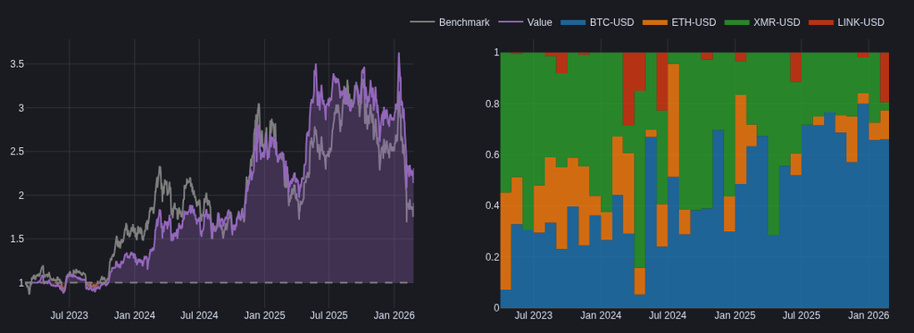

```python
fig = vbt.make_subplots(rows=1, cols=2)
fig.update_layout(width=1000,height=400)
pf1.plot_cumulative_returns(column=1, add_trace_kwargs=dict(row=1, col=1), fig=fig)
pfo1.plot(column=1, add_trace_kwargs=dict(row=1, col=2), fig=fig)
```

So the Sharpe ratio $S_a=1.24$ is not ideal if we're chasing alpha (i.e. profitable strategy whether the market is bearish/bullish), but if we're just looking to increase our beta (increasing exposure to the market swings to capture the most price action) then this is starting to look better.

```python
initial_weights = np.array([1 / len(data.symbols)] * len(data.symbols))
pfo2 = vbt.PortfolioOptimizer.from_pypfopt(
    prices=data.get("Close"),
    every="1M",
    weight_bounds=(-1, 1),
    objectives=["transaction_cost"],
    w_prev=initial_weights,
    k=0.001,
    target=vbt.Param([
        "max_sharpe",
        "min_volatility",
        "max_quadratic_utility"
    ])
)
```

```python
pf2 = pfo2.simulate(data, freq="1d")
print(f"{pf2.sharpe_ratio}\n\n{pf2.max_drawdown}\n\n{pf2.annualized_return}")
```

```
target
max_sharpe               0.577411
min_volatility           0.716948
max_quadratic_utility    1.337973
Name: sharpe_ratio, dtype: float64

target
max_sharpe              -0.409129
min_volatility          -0.342790
max_quadratic_utility   -0.407796
Name: max_drawdown, dtype: float64

target
max_sharpe               0.176048
min_volatility           0.235928
max_quadratic_utility    0.719952
Name: annualized_return, dtype: float64
```

If we consider a per-trade transction cost of $0.1\%$ of the amount traded, the story changes; we now are actually less profitable with an atrocious decrease of $> 60\%$ in annualized returns (for a `max_sharpe` optimization objective).

However, in optimizing for minimum volatility, including transaction fees only shifts the annualized returns down by about $10\%$.

### Conclusion

Optimizing portfolios for certain target metrics periodically and rebalancing can lead to promising results for beta-seeking strategies. However this all depends on the optimization constraints, the target parameter, and of course the assets considered.

For those of you interested, there is web-app service called [Portfolio Visualizer](https://www.portfoliovisualizer.com/optimize-portfolio) where you can optimize portfolios subject to different constraints.

[figure not shown]

Disclaimer:

Please do not distribute this notebook.

**The analysis in this material is provided for information only and should not be construed as advice to buy any cryptocurrency**